# Risk Factor Analysis

## Outcome Variable

**Outcome Variable:** stunted

## Predictor Variables

**Intervention Variable:** exclfeed6

**Adjustment Set:**

unadjusted

## Stratifying Variables

The analysis was stratified on these variable(s):

- agecat
- studyid
- country

## Data Summary

| agecat | studyid | country | exclfeed6 | stunted | n_cell | n | outcome_variable |
| --- | --- | --- | --- | --- | --- | --- | --- |
| Birth | ki0047075b-MAL-ED | BANGLADESH | 1 | 0 | 26 | 205 | stunted |
| Birth | ki0047075b-MAL-ED | BANGLADESH | 1 | 1 | 5 | 205 | stunted |
| Birth | ki0047075b-MAL-ED | BANGLADESH | 0 | 0 | 143 | 205 | stunted |
| Birth | ki0047075b-MAL-ED | BANGLADESH | 0 | 1 | 31 | 205 | stunted |
| Birth | ki0047075b-MAL-ED | BRAZIL | 1 | 0 | 0 | 60 | stunted |
| Birth | ki0047075b-MAL-ED | BRAZIL | 1 | 1 | 2 | 60 | stunted |
| Birth | ki0047075b-MAL-ED | BRAZIL | 0 | 0 | 51 | 60 | stunted |
| Birth | ki0047075b-MAL-ED | BRAZIL | 0 | 1 | 7 | 60 | stunted |
| Birth | ki0047075b-MAL-ED | INDIA | 1 | 0 | 0 | 39 | stunted |
| Birth | ki0047075b-MAL-ED | INDIA | 1 | 1 | 1 | 39 | stunted |
| Birth | ki0047075b-MAL-ED | INDIA | 0 | 0 | 31 | 39 | stunted |
| Birth | ki0047075b-MAL-ED | INDIA | 0 | 1 | 7 | 39 | stunted |
| Birth | ki0047075b-MAL-ED | NEPAL | 1 | 0 | 2 | 24 | stunted |
| Birth | ki0047075b-MAL-ED | NEPAL | 1 | 1 | 0 | 24 | stunted |
| Birth | ki0047075b-MAL-ED | NEPAL | 0 | 0 | 21 | 24 | stunted |
| Birth | ki0047075b-MAL-ED | NEPAL | 0 | 1 | 1 | 24 | stunted |
| Birth | ki0047075b-MAL-ED | PERU | 1 | 0 | 2 | 213 | stunted |
| Birth | ki0047075b-MAL-ED | PERU | 1 | 1 | 0 | 213 | stunted |
| Birth | ki0047075b-MAL-ED | PERU | 0 | 0 | 185 | 213 | stunted |
| Birth | ki0047075b-MAL-ED | PERU | 0 | 1 | 26 | 213 | stunted |
| Birth | ki0047075b-MAL-ED | SOUTH AFRICA | 1 | 0 | 0 | 91 | stunted |
| Birth | ki0047075b-MAL-ED | SOUTH AFRICA | 1 | 1 | 0 | 91 | stunted |
| Birth | ki0047075b-MAL-ED | SOUTH AFRICA | 0 | 0 | 83 | 91 | stunted |
| Birth | ki0047075b-MAL-ED | SOUTH AFRICA | 0 | 1 | 8 | 91 | stunted |
| Birth | ki0047075b-MAL-ED | TANZANIA, UNITED REPUBLIC OF | 1 | 0 | 0 | 113 | stunted |
| Birth | ki0047075b-MAL-ED | TANZANIA, UNITED REPUBLIC OF | 1 | 1 | 0 | 113 | stunted |
| Birth | ki0047075b-MAL-ED | TANZANIA, UNITED REPUBLIC OF | 0 | 0 | 92 | 113 | stunted |
| Birth | ki0047075b-MAL-ED | TANZANIA, UNITED REPUBLIC OF | 0 | 1 | 21 | 113 | stunted |
| Birth | ki1000108-CMC-V-BCS-2002 | INDIA | 1 | 0 | 7 | 7 | stunted |
| Birth | ki1000108-CMC-V-BCS-2002 | INDIA | 1 | 1 | 0 | 7 | stunted |

[output cut: 170 more lines]

The following strata were considered:

- agecat: 24 months, studyid: ki0047075b-MAL-ED, country: BANGLADESH
- agecat: 24 months, studyid: ki0047075b-MAL-ED, country: BRAZIL
- agecat: 24 months, studyid: ki0047075b-MAL-ED, country: INDIA
- agecat: 24 months, studyid: ki0047075b-MAL-ED, country: NEPAL
- agecat: 24 months, studyid: ki0047075b-MAL-ED, country: PERU
- agecat: 24 months, studyid: ki0047075b-MAL-ED, country: SOUTH AFRICA
- agecat: 24 months, studyid: ki0047075b-MAL-ED, country: TANZANIA, UNITED REPUBLIC OF
- agecat: 24 months, studyid: ki1000108-CMC-V-BCS-2002, country: INDIA
- agecat: 24 months, studyid: ki1000108-IRC, country: INDIA
- agecat: 24 months, studyid: ki1000109-EE, country: PAKISTAN
- agecat: 24 months, studyid: ki1017093b-PROVIDE, country: BANGLADESH
- agecat: 24 months, studyid: ki1101329-Keneba, country: GAMBIA
- agecat: 24 months, studyid: ki1113344-GMS-Nepal, country: NEPAL
- agecat: 24 months, studyid: ki1148112-LCNI-5, country: MALAWI
- agecat: 24 months, studyid: kiGH5241-JiVitA-3, country: BANGLADESH
- agecat: 24 months, studyid: kiGH5241-JiVitA-4, country: BANGLADESH
- agecat: 6 months, studyid: ki0047075b-MAL-ED, country: BANGLADESH
- agecat: 6 months, studyid: ki0047075b-MAL-ED, country: BRAZIL
- agecat: 6 months, studyid: ki0047075b-MAL-ED, country: INDIA
- agecat: 6 months, studyid: ki0047075b-MAL-ED, country: NEPAL
- agecat: 6 months, studyid: ki0047075b-MAL-ED, country: PERU
- agecat: 6 months, studyid: ki0047075b-MAL-ED, country: SOUTH AFRICA
- agecat: 6 months, studyid: ki0047075b-MAL-ED, country: TANZANIA, UNITED REPUBLIC OF
- agecat: 6 months, studyid: ki1000108-CMC-V-BCS-2002, country: INDIA
- agecat: 6 months, studyid: ki1000108-IRC, country: INDIA
- agecat: 6 months, studyid: ki1000109-EE, country: PAKISTAN
- agecat: 6 months, studyid: ki1000304b-SAS-CompFeed, country: INDIA
- agecat: 6 months, studyid: ki1000304b-SAS-FoodSuppl, country: INDIA
- agecat: 6 months, studyid: ki1017093b-PROVIDE, country: BANGLADESH
- agecat: 6 months, studyid: ki1101329-Keneba, country: GAMBIA
- agecat: 6 months, studyid: ki1113344-GMS-Nepal, country: NEPAL
- agecat: 6 months, studyid: ki1148112-LCNI-5, country: MALAWI
- agecat: 6 months, studyid: kiGH5241-JiVitA-3, country: BANGLADESH
- agecat: 6 months, studyid: kiGH5241-JiVitA-4, country: BANGLADESH
- agecat: Birth, studyid: ki0047075b-MAL-ED, country: BANGLADESH
- agecat: Birth, studyid: ki0047075b-MAL-ED, country: BRAZIL
- agecat: Birth, studyid: ki0047075b-MAL-ED, country: INDIA
- agecat: Birth, studyid: ki0047075b-MAL-ED, country: NEPAL
- agecat: Birth, studyid: ki0047075b-MAL-ED, country: PERU
- agecat: Birth, studyid: ki0047075b-MAL-ED, country: SOUTH AFRICA
- agecat: Birth, studyid: ki0047075b-MAL-ED, country: TANZANIA, UNITED REPUBLIC OF
- agecat: Birth, studyid: ki1000108-CMC-V-BCS-2002, country: INDIA
- agecat: Birth, studyid: ki1000108-IRC, country: INDIA
- agecat: Birth, studyid: ki1000109-EE, country: PAKISTAN
- agecat: Birth, studyid: ki1000304b-SAS-CompFeed, country: INDIA
- agecat: Birth, studyid: ki1017093b-PROVIDE, country: BANGLADESH
- agecat: Birth, studyid: ki1101329-Keneba, country: GAMBIA
- agecat: Birth, studyid: ki1113344-GMS-Nepal, country: NEPAL
- agecat: Birth, studyid: kiGH5241-JiVitA-3, country: BANGLADESH
- agecat: Birth, studyid: kiGH5241-JiVitA-4, country: BANGLADESH

### Dropped Strata

Some strata were dropped due to rare outcomes:

- agecat: Birth, studyid: ki0047075b-MAL-ED, country: BRAZIL
- agecat: Birth, studyid: ki0047075b-MAL-ED, country: INDIA
- agecat: Birth, studyid: ki0047075b-MAL-ED, country: NEPAL
- agecat: Birth, studyid: ki0047075b-MAL-ED, country: PERU
- agecat: Birth, studyid: ki0047075b-MAL-ED, country: SOUTH AFRICA
- agecat: Birth, studyid: ki0047075b-MAL-ED, country: TANZANIA, UNITED REPUBLIC OF
- agecat: Birth, studyid: ki1000108-CMC-V-BCS-2002, country: INDIA
- agecat: Birth, studyid: ki1000108-IRC, country: INDIA
- agecat: Birth, studyid: ki1000109-EE, country: PAKISTAN
- agecat: 6 months, studyid: ki0047075b-MAL-ED, country: BRAZIL
- agecat: 6 months, studyid: ki0047075b-MAL-ED, country: INDIA
- agecat: 6 months, studyid: ki0047075b-MAL-ED, country: NEPAL
- agecat: 6 months, studyid: ki0047075b-MAL-ED, country: PERU
- agecat: 6 months, studyid: ki0047075b-MAL-ED, country: SOUTH AFRICA
- agecat: 6 months, studyid: ki0047075b-MAL-ED, country: TANZANIA, UNITED REPUBLIC OF
- agecat: 6 months, studyid: ki1000108-CMC-V-BCS-2002, country: INDIA
- agecat: 6 months, studyid: ki1000108-IRC, country: INDIA
- agecat: 6 months, studyid: ki1000109-EE, country: PAKISTAN
- agecat: 6 months, studyid: ki1000304b-SAS-FoodSuppl, country: INDIA
- agecat: 24 months, studyid: ki0047075b-MAL-ED, country: BRAZIL
- agecat: 24 months, studyid: ki0047075b-MAL-ED, country: INDIA
- agecat: 24 months, studyid: ki0047075b-MAL-ED, country: NEPAL
- agecat: 24 months, studyid: ki0047075b-MAL-ED, country: PERU
- agecat: 24 months, studyid: ki0047075b-MAL-ED, country: SOUTH AFRICA
- agecat: 24 months, studyid: ki0047075b-MAL-ED, country: TANZANIA, UNITED REPUBLIC OF
- agecat: 24 months, studyid: ki1000108-CMC-V-BCS-2002, country: INDIA
- agecat: 24 months, studyid: ki1000108-IRC, country: INDIA
- agecat: 24 months, studyid: ki1000109-EE, country: PAKISTAN

## Methods Detail

We’re interested in the causal parameters $E[Y_a]$ for all values of $a \in \mathcal{A}$. These parameters represent the mean outcome if, possibly contrary to fact, we intervened to set all units to have $A=a$. Under the randomization and positivity assumptions, these are identified by the statistical parameters $\psi_a=E_W[E_{Y|A,W}(Y|A=a,W)]$. In addition, we’re interested in the mean of $Y$, $E[Y]$ under no intervention (the observed mean). We will estimate these parameters by using SuperLearner to fit the relevant likelihood factors – $E_{Y|A,W}(Y|A=a,W)$ and $p(A=a|W)$, and then updating our likelihood fit using a joint TMLE.

For unadjusted analyses ($W=\{\}$), initial likelihoods were estimated using Lrnr_glm to estimate the simple $E(Y|A)$ and Lrnr_mean to estimate $p(A)$. For adjusted analyses, a small library containing Lrnr_glmnet, Lrnr_xgboost, and Lrnr_mean was used.

Having estimated these parameters, we will then use the delta method to estimate relative risks and attributable risks relative to a prespecified baseline level of $A$.

# Results Detail

## Results Plots

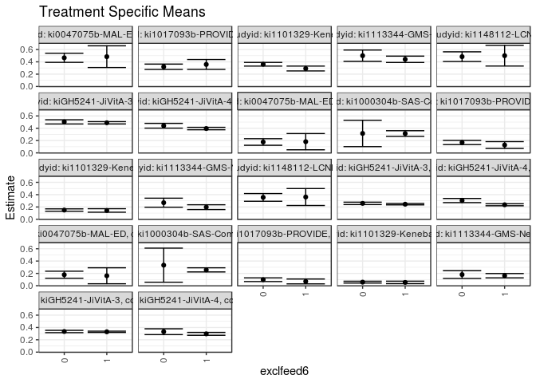

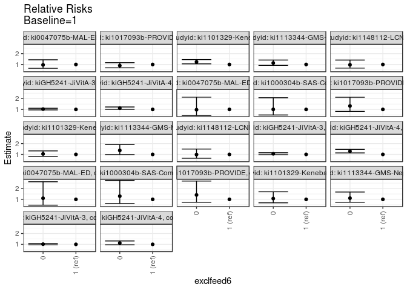

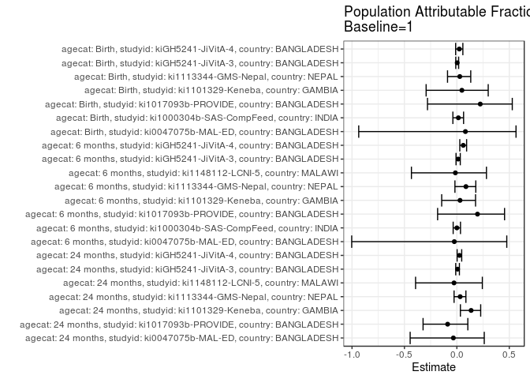

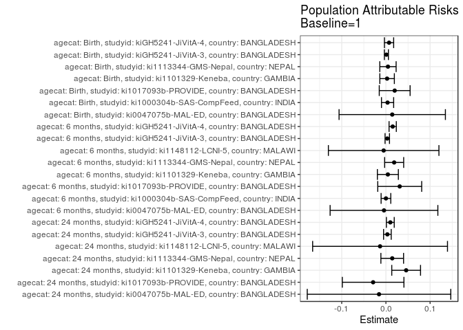

## Results Table

### Parameter: TSM

| agecat | studyid | country | intervention_level | baseline_level | estimate | ci_lower | ci_upper |
| --- | --- | --- | --- | --- | --- | --- | --- |
| Birth | ki0047075b-MAL-ED | BANGLADESH | 1 | NA | 0.1612903 | 0.0315010 | 0.2910797 |
| Birth | ki0047075b-MAL-ED | BANGLADESH | 0 | NA | 0.1781609 | 0.1211662 | 0.2351557 |
| Birth | ki1000304b-SAS-CompFeed | INDIA | 1 | NA | 0.2572254 | 0.2236819 | 0.2907690 |
| Birth | ki1000304b-SAS-CompFeed | INDIA | 0 | NA | 0.3333333 | 0.0564891 | 0.6101775 |
| Birth | ki1017093b-PROVIDE | BANGLADESH | 1 | NA | 0.0691824 | 0.0297019 | 0.1086629 |
| Birth | ki1017093b-PROVIDE | BANGLADESH | 0 | NA | 0.0973684 | 0.0675336 | 0.1272033 |
| Birth | ki1101329-Keneba | GAMBIA | 1 | NA | 0.0536082 | 0.0335551 | 0.0736614 |
| Birth | ki1101329-Keneba | GAMBIA | 0 | NA | 0.0577342 | 0.0426409 | 0.0728275 |
| Birth | ki1113344-GMS-Nepal | NEPAL | 1 | NA | 0.1622912 | 0.1269549 | 0.1976275 |
| Birth | ki1113344-GMS-Nepal | NEPAL | 0 | NA | 0.1805556 | 0.1176748 | 0.2434364 |
| Birth | kiGH5241-JiVitA-3 | BANGLADESH | 1 | NA | 0.3299847 | 0.3197472 | 0.3402222 |
| Birth | kiGH5241-JiVitA-3 | BANGLADESH | 0 | NA | 0.3349041 | 0.3163239 | 0.3534842 |
| Birth | kiGH5241-JiVitA-4 | BANGLADESH | 1 | NA | 0.2964728 | 0.2731669 | 0.3197787 |
| Birth | kiGH5241-JiVitA-4 | BANGLADESH | 0 | NA | 0.3314607 | 0.2842582 | 0.3786632 |
| 6 months | ki0047075b-MAL-ED | BANGLADESH | 1 | NA | 0.1818182 | 0.0499388 | 0.3136975 |
| 6 months | ki0047075b-MAL-ED | BANGLADESH | 0 | NA | 0.1767677 | 0.1235176 | 0.2300177 |
| 6 months | ki1000304b-SAS-CompFeed | INDIA | 1 | NA | 0.3139842 | 0.2679102 | 0.3600581 |
| 6 months | ki1000304b-SAS-CompFeed | INDIA | 0 | NA | 0.3157895 | 0.1014523 | 0.5301266 |
| 6 months | ki1017093b-PROVIDE | BANGLADESH | 1 | NA | 0.1276596 | 0.0725321 | 0.1827870 |
| 6 months | ki1017093b-PROVIDE | BANGLADESH | 0 | NA | 0.1684665 | 0.1343461 | 0.2025869 |
| 6 months | ki1101329-Keneba | GAMBIA | 1 | NA | 0.1433447 | 0.1149651 | 0.1717244 |
| 6 months | ki1101329-Keneba | GAMBIA | 0 | NA | 0.1497731 | 0.1305319 | 0.1690142 |
| 6 months | ki1113344-GMS-Nepal | NEPAL | 1 | NA | 0.1970443 | 0.1583177 | 0.2357710 |
| 6 months | ki1113344-GMS-Nepal | NEPAL | 0 | NA | 0.2695035 | 0.1961996 | 0.3428075 |
| 6 months | ki1148112-LCNI-5 | MALAWI | 1 | NA | 0.3617021 | 0.2240807 | 0.4993236 |
| 6 months | ki1148112-LCNI-5 | MALAWI | 0 | NA | 0.3555556 | 0.2928937 | 0.4182174 |
| 6 months | kiGH5241-JiVitA-3 | BANGLADESH | 1 | NA | 0.2451494 | 0.2338566 | 0.2564423 |
| 6 months | kiGH5241-JiVitA-3 | BANGLADESH | 0 | NA | 0.2586890 | 0.2392664 | 0.2781115 |
| 6 months | kiGH5241-JiVitA-4 | BANGLADESH | 1 | NA | 0.2358263 | 0.2196344 | 0.2520182 |
| 6 months | kiGH5241-JiVitA-4 | BANGLADESH | 0 | NA | 0.3043933 | 0.2707847 | 0.3380019 |
| 24 months | ki0047075b-MAL-ED | BANGLADESH | 1 | NA | 0.4838710 | 0.3075220 | 0.6602200 |
| 24 months | ki0047075b-MAL-ED | BANGLADESH | 0 | NA | 0.4655172 | 0.3912205 | 0.5398140 |
| 24 months | ki1017093b-PROVIDE | BANGLADESH | 1 | NA | 0.3576642 | 0.2773333 | 0.4379951 |
| 24 months | ki1017093b-PROVIDE | BANGLADESH | 0 | NA | 0.3197279 | 0.2761630 | 0.3632928 |
| 24 months | ki1101329-Keneba | GAMBIA | 1 | NA | 0.2912621 | 0.2520091 | 0.3305151 |
| 24 months | ki1101329-Keneba | GAMBIA | 0 | NA | 0.3607214 | 0.3309186 | 0.3905243 |
| 24 months | ki1113344-GMS-Nepal | NEPAL | 1 | NA | 0.4410112 | 0.3893801 | 0.4926424 |
| 24 months | ki1113344-GMS-Nepal | NEPAL | 0 | NA | 0.5000000 | 0.4081185 | 0.5918815 |
| 24 months | ki1148112-LCNI-5 | MALAWI | 1 | NA | 0.5000000 | 0.3314881 | 0.6685119 |
| 24 months | ki1148112-LCNI-5 | MALAWI | 0 | NA | 0.4838710 | 0.4049889 | 0.5627530 |
| 24 months | kiGH5241-JiVitA-3 | BANGLADESH | 1 | NA | 0.4887640 | 0.4698518 | 0.5076763 |
| 24 months | kiGH5241-JiVitA-3 | BANGLADESH | 0 | NA | 0.5034130 | 0.4696016 | 0.5372243 |
| 24 months | kiGH5241-JiVitA-4 | BANGLADESH | 1 | NA | 0.3951220 | 0.3755266 | 0.4147173 |
| 24 months | kiGH5241-JiVitA-4 | BANGLADESH | 0 | NA | 0.4406964 | 0.4021535 | 0.4792394 |

### Parameter: E(Y)

| agecat | studyid | country | intervention_level | baseline_level | estimate | ci_lower | ci_upper |
| --- | --- | --- | --- | --- | --- | --- | --- |
| Birth | ki0047075b-MAL-ED | BANGLADESH | NA | NA | 0.1756098 | 0.1233973 | 0.2278222 |
| Birth | ki1000304b-SAS-CompFeed | INDIA | NA | NA | 0.2609890 | 0.2179233 | 0.3040547 |
| Birth | ki1017093b-PROVIDE | BANGLADESH | NA | NA | 0.0890538 | 0.0649864 | 0.1131212 |
| Birth | ki1101329-Keneba | GAMBIA | NA | NA | 0.0563079 | 0.0442416 | 0.0683742 |
| Birth | ki1113344-GMS-Nepal | NEPAL | NA | NA | 0.1669627 | 0.1361293 | 0.1977961 |
| Birth | kiGH5241-JiVitA-3 | BANGLADESH | NA | NA | 0.3310735 | 0.3218922 | 0.3402548 |
| Birth | kiGH5241-JiVitA-4 | BANGLADESH | NA | NA | 0.3035714 | 0.2824097 | 0.3247332 |
| 6 months | ki0047075b-MAL-ED | BANGLADESH | NA | NA | 0.1774892 | 0.1281103 | 0.2268680 |
| 6 months | ki1000304b-SAS-CompFeed | INDIA | NA | NA | 0.3140704 | 0.2712850 | 0.3568557 |
| 6 months | ki1017093b-PROVIDE | BANGLADESH | NA | NA | 0.1589404 | 0.1297581 | 0.1881227 |
| 6 months | ki1101329-Keneba | GAMBIA | NA | NA | 0.1477987 | 0.1318701 | 0.1637274 |
| 6 months | ki1113344-GMS-Nepal | NEPAL | NA | NA | 0.2157221 | 0.1812209 | 0.2502233 |
| 6 months | ki1148112-LCNI-5 | MALAWI | NA | NA | 0.3566176 | 0.2995882 | 0.4136471 |
| 6 months | kiGH5241-JiVitA-3 | BANGLADESH | NA | NA | 0.2482578 | 0.2382387 | 0.2582768 |
| 6 months | kiGH5241-JiVitA-4 | BANGLADESH | NA | NA | 0.2511704 | 0.2362353 | 0.2661055 |
| 24 months | ki0047075b-MAL-ED | BANGLADESH | NA | NA | 0.4682927 | 0.3998183 | 0.5367670 |
| 24 months | ki1017093b-PROVIDE | BANGLADESH | NA | NA | 0.3287197 | 0.2903909 | 0.3670485 |
| 24 months | ki1101329-Keneba | GAMBIA | NA | NA | 0.3370787 | 0.3132517 | 0.3609056 |
| 24 months | ki1113344-GMS-Nepal | NEPAL | NA | NA | 0.4553191 | 0.4102488 | 0.5003895 |
| 24 months | ki1148112-LCNI-5 | MALAWI | NA | NA | 0.4867725 | 0.4153250 | 0.5582200 |
| 24 months | kiGH5241-JiVitA-3 | BANGLADESH | NA | NA | 0.4921384 | 0.4750959 | 0.5091808 |
| 24 months | kiGH5241-JiVitA-4 | BANGLADESH | NA | NA | 0.4050965 | 0.3867240 | 0.4234689 |

### Parameter: RR

| agecat | studyid | country | intervention_level | baseline_level | estimate | ci_lower | ci_upper |
| --- | --- | --- | --- | --- | --- | --- | --- |
| Birth | ki0047075b-MAL-ED | BANGLADESH | 1 | 1 | 1.0000000 | 1.0000000 | 1.000000 |
| Birth | ki0047075b-MAL-ED | BANGLADESH | 0 | 1 | 1.1045977 | 0.4646502 | 2.625924 |
| Birth | ki1000304b-SAS-CompFeed | INDIA | 1 | 1 | 1.0000000 | 1.0000000 | 1.000000 |
| Birth | ki1000304b-SAS-CompFeed | INDIA | 0 | 1 | 1.2958801 | 0.6113712 | 2.746785 |
| Birth | ki1017093b-PROVIDE | BANGLADESH | 1 | 1 | 1.0000000 | 1.0000000 | 1.000000 |
| Birth | ki1017093b-PROVIDE | BANGLADESH | 0 | 1 | 1.4074163 | 0.7364045 | 2.689854 |
| Birth | ki1101329-Keneba | GAMBIA | 1 | 1 | 1.0000000 | 1.0000000 | 1.000000 |
| Birth | ki1101329-Keneba | GAMBIA | 0 | 1 | 1.0769650 | 0.6823439 | 1.699808 |
| Birth | ki1113344-GMS-Nepal | NEPAL | 1 | 1 | 1.0000000 | 1.0000000 | 1.000000 |
| Birth | ki1113344-GMS-Nepal | NEPAL | 0 | 1 | 1.1125408 | 0.7378028 | 1.677612 |
| Birth | kiGH5241-JiVitA-3 | BANGLADESH | 1 | 1 | 1.0000000 | 1.0000000 | 1.000000 |
| Birth | kiGH5241-JiVitA-3 | BANGLADESH | 0 | 1 | 1.0149079 | 0.9539409 | 1.079771 |
| Birth | kiGH5241-JiVitA-4 | BANGLADESH | 1 | 1 | 1.0000000 | 1.0000000 | 1.000000 |
| Birth | kiGH5241-JiVitA-4 | BANGLADESH | 0 | 1 | 1.1180137 | 0.9527556 | 1.311936 |
| 6 months | ki0047075b-MAL-ED | BANGLADESH | 1 | 1 | 1.0000000 | 1.0000000 | 1.000000 |
| 6 months | ki0047075b-MAL-ED | BANGLADESH | 0 | 1 | 0.9722222 | 0.4432703 | 2.132369 |
| 6 months | ki1000304b-SAS-CompFeed | INDIA | 1 | 1 | 1.0000000 | 1.0000000 | 1.000000 |
| 6 months | ki1000304b-SAS-CompFeed | INDIA | 0 | 1 | 1.0057497 | 0.4866253 | 2.078668 |
| 6 months | ki1017093b-PROVIDE | BANGLADESH | 1 | 1 | 1.0000000 | 1.0000000 | 1.000000 |
| 6 months | ki1017093b-PROVIDE | BANGLADESH | 0 | 1 | 1.3196544 | 0.8190592 | 2.126205 |
| 6 months | ki1101329-Keneba | GAMBIA | 1 | 1 | 1.0000000 | 1.0000000 | 1.000000 |
| 6 months | ki1101329-Keneba | GAMBIA | 0 | 1 | 1.0448455 | 0.8251901 | 1.322970 |
| 6 months | ki1113344-GMS-Nepal | NEPAL | 1 | 1 | 1.0000000 | 1.0000000 | 1.000000 |
| 6 months | ki1113344-GMS-Nepal | NEPAL | 0 | 1 | 1.3677305 | 0.9778296 | 1.913101 |
| 6 months | ki1148112-LCNI-5 | MALAWI | 1 | 1 | 1.0000000 | 1.0000000 | 1.000000 |
| 6 months | ki1148112-LCNI-5 | MALAWI | 0 | 1 | 0.9830065 | 0.6463228 | 1.495076 |
| 6 months | kiGH5241-JiVitA-3 | BANGLADESH | 1 | 1 | 1.0000000 | 1.0000000 | 1.000000 |
| 6 months | kiGH5241-JiVitA-3 | BANGLADESH | 0 | 1 | 1.0552296 | 0.9685890 | 1.149620 |
| 6 months | kiGH5241-JiVitA-4 | BANGLADESH | 1 | 1 | 1.0000000 | 1.0000000 | 1.000000 |
| 6 months | kiGH5241-JiVitA-4 | BANGLADESH | 0 | 1 | 1.2907522 | 1.1362186 | 1.466303 |
| 24 months | ki0047075b-MAL-ED | BANGLADESH | 1 | 1 | 1.0000000 | 1.0000000 | 1.000000 |
| 24 months | ki0047075b-MAL-ED | BANGLADESH | 0 | 1 | 0.9620690 | 0.6462701 | 1.432183 |
| 24 months | ki1017093b-PROVIDE | BANGLADESH | 1 | 1 | 1.0000000 | 1.0000000 | 1.000000 |
| 24 months | ki1017093b-PROVIDE | BANGLADESH | 0 | 1 | 0.8939331 | 0.6874113 | 1.162501 |
| 24 months | ki1101329-Keneba | GAMBIA | 1 | 1 | 1.0000000 | 1.0000000 | 1.000000 |
| 24 months | ki1101329-Keneba | GAMBIA | 0 | 1 | 1.2384770 | 1.0573908 | 1.450576 |
| 24 months | ki1113344-GMS-Nepal | NEPAL | 1 | 1 | 1.0000000 | 1.0000000 | 1.000000 |
| 24 months | ki1113344-GMS-Nepal | NEPAL | 0 | 1 | 1.1337580 | 0.9117855 | 1.409769 |
| 24 months | ki1148112-LCNI-5 | MALAWI | 1 | 1 | 1.0000000 | 1.0000000 | 1.000000 |
| 24 months | ki1148112-LCNI-5 | MALAWI | 0 | 1 | 0.9677419 | 0.6655301 | 1.407186 |
| 24 months | kiGH5241-JiVitA-3 | BANGLADESH | 1 | 1 | 1.0000000 | 1.0000000 | 1.000000 |
| 24 months | kiGH5241-JiVitA-3 | BANGLADESH | 0 | 1 | 1.0299714 | 0.9556933 | 1.110022 |
| 24 months | kiGH5241-JiVitA-4 | BANGLADESH | 1 | 1 | 1.0000000 | 1.0000000 | 1.000000 |
| 24 months | kiGH5241-JiVitA-4 | BANGLADESH | 0 | 1 | 1.1153428 | 1.0143420 | 1.226400 |

### Parameter: PAR

| agecat | studyid | country | intervention_level | baseline_level | estimate | ci_lower | ci_upper |
| --- | --- | --- | --- | --- | --- | --- | --- |
| Birth | ki0047075b-MAL-ED | BANGLADESH | 1 | NA | 0.0143194 | -0.1059999 | 0.1346388 |
| Birth | ki1000304b-SAS-CompFeed | INDIA | 1 | NA | 0.0037636 | -0.0100156 | 0.0175428 |
| Birth | ki1017093b-PROVIDE | BANGLADESH | 1 | NA | 0.0198714 | -0.0150333 | 0.0547762 |
| Birth | ki1101329-Keneba | GAMBIA | 1 | NA | 0.0026997 | -0.0137230 | 0.0191223 |
| Birth | ki1113344-GMS-Nepal | NEPAL | 1 | NA | 0.0046715 | -0.0137890 | 0.0231320 |
| Birth | kiGH5241-JiVitA-3 | BANGLADESH | 1 | NA | 0.0010888 | -0.0034862 | 0.0056639 |
| Birth | kiGH5241-JiVitA-4 | BANGLADESH | 1 | NA | 0.0070986 | -0.0033471 | 0.0175442 |
| 6 months | ki0047075b-MAL-ED | BANGLADESH | 1 | NA | -0.0043290 | -0.1262357 | 0.1175777 |
| 6 months | ki1000304b-SAS-CompFeed | INDIA | 1 | NA | 0.0000862 | -0.0108674 | 0.0110398 |
| 6 months | ki1017093b-PROVIDE | BANGLADESH | 1 | NA | 0.0312808 | -0.0184360 | 0.0809976 |
| 6 months | ki1101329-Keneba | GAMBIA | 1 | NA | 0.0044540 | -0.0193031 | 0.0282112 |
| 6 months | ki1113344-GMS-Nepal | NEPAL | 1 | NA | 0.0186778 | -0.0028573 | 0.0402129 |
| 6 months | ki1148112-LCNI-5 | MALAWI | 1 | NA | -0.0050845 | -0.1301713 | 0.1200023 |
| 6 months | kiGH5241-JiVitA-3 | BANGLADESH | 1 | NA | 0.0031083 | -0.0019105 | 0.0081271 |
| 6 months | kiGH5241-JiVitA-4 | BANGLADESH | 1 | NA | 0.0153441 | 0.0071328 | 0.0235555 |
| 24 months | ki0047075b-MAL-ED | BANGLADESH | 1 | NA | -0.0155783 | -0.1780042 | 0.1468476 |
| 24 months | ki1017093b-PROVIDE | BANGLADESH | 1 | NA | -0.0289445 | -0.0986804 | 0.0407913 |
| 24 months | ki1101329-Keneba | GAMBIA | 1 | NA | 0.0458165 | 0.0132650 | 0.0783680 |
| 24 months | ki1113344-GMS-Nepal | NEPAL | 1 | NA | 0.0143079 | -0.0113581 | 0.0399739 |
| 24 months | ki1148112-LCNI-5 | MALAWI | 1 | NA | -0.0132275 | -0.1658197 | 0.1393646 |
| 24 months | kiGH5241-JiVitA-3 | BANGLADESH | 1 | NA | 0.0033743 | -0.0052657 | 0.0120143 |
| 24 months | kiGH5241-JiVitA-4 | BANGLADESH | 1 | NA | 0.0099745 | 0.0010892 | 0.0188598 |

### Parameter: PAF

| agecat | studyid | country | intervention_level | baseline_level | estimate | ci_lower | ci_upper |
| --- | --- | --- | --- | --- | --- | --- | --- |
| Birth | ki0047075b-MAL-ED | BANGLADESH | 1 | NA | 0.0815412 | -0.9360258 | 0.5642793 |
| Birth | ki1000304b-SAS-CompFeed | INDIA | 1 | NA | 0.0144204 | -0.0378960 | 0.0640998 |
| Birth | ki1017093b-PROVIDE | BANGLADESH | 1 | NA | 0.2231394 | -0.2801119 | 0.5285472 |
| Birth | ki1101329-Keneba | GAMBIA | 1 | NA | 0.0479447 | -0.2931027 | 0.2990430 |
| Birth | ki1113344-GMS-Nepal | NEPAL | 1 | NA | 0.0279795 | -0.0890382 | 0.1324236 |
| Birth | kiGH5241-JiVitA-3 | BANGLADESH | 1 | NA | 0.0032888 | -0.0106260 | 0.0170121 |
| Birth | kiGH5241-JiVitA-4 | BANGLADESH | 1 | NA | 0.0233836 | -0.0116263 | 0.0571820 |
| 6 months | ki0047075b-MAL-ED | BANGLADESH | 1 | NA | -0.0243902 | -1.0028399 | 0.4760563 |
| 6 months | ki1000304b-SAS-CompFeed | INDIA | 1 | NA | 0.0002744 | -0.0352245 | 0.0345560 |
| 6 months | ki1017093b-PROVIDE | BANGLADESH | 1 | NA | 0.1968085 | -0.1834950 | 0.4549056 |
| 6 months | ki1101329-Keneba | GAMBIA | 1 | NA | 0.0301358 | -0.1446658 | 0.1782435 |
| 6 months | ki1113344-GMS-Nepal | NEPAL | 1 | NA | 0.0865826 | -0.0183705 | 0.1807193 |
| 6 months | ki1148112-LCNI-5 | MALAWI | 1 | NA | -0.0142575 | -0.4333092 | 0.2822775 |
| 6 months | kiGH5241-JiVitA-3 | BANGLADESH | 1 | NA | 0.0125205 | -0.0079206 | 0.0325469 |
| 6 months | kiGH5241-JiVitA-4 | BANGLADESH | 1 | NA | 0.0610905 | 0.0280482 | 0.0930095 |
| 24 months | ki0047075b-MAL-ED | BANGLADESH | 1 | NA | -0.0332661 | -0.4454664 | 0.2613879 |
| 24 months | ki1017093b-PROVIDE | BANGLADESH | 1 | NA | -0.0880522 | -0.3223096 | 0.1047046 |
| 24 months | ki1101329-Keneba | GAMBIA | 1 | NA | 0.1359223 | 0.0338147 | 0.2272391 |
| 24 months | ki1113344-GMS-Nepal | NEPAL | 1 | NA | 0.0314239 | -0.0266742 | 0.0862343 |
| 24 months | ki1148112-LCNI-5 | MALAWI | 1 | NA | -0.0271739 | -0.3937793 | 0.2430034 |
| 24 months | kiGH5241-JiVitA-3 | BANGLADESH | 1 | NA | 0.0068564 | -0.0108513 | 0.0242540 |
| 24 months | kiGH5241-JiVitA-4 | BANGLADESH | 1 | NA | 0.0246225 | 0.0025251 | 0.0462304 |